# Exercise Classification on Activity Tracker Data

Paul Nice

28 July 2017

## Initial Review of Data

On initial review of the data there were significant numbers of the predictors that contained multiple missing values. Indeed there were 100 variables that were more than 50% missing (in most cases 95%+). Given the volume of missing observations imputation of new values for these predictors would have added little value to the anslysis hence these predictors were discounted

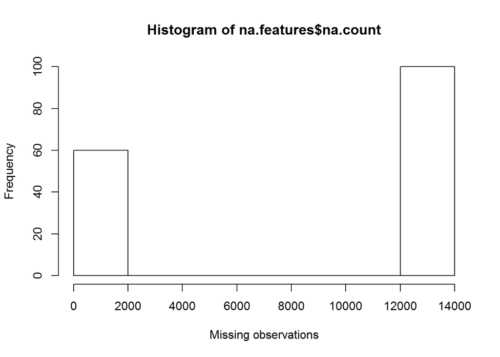

```r
hist(na.features$na.count, title="Missing observations per predictor",
     xlab="Missing observations")
```

Removing these predictors left a small number of missing values these were imputed using the knnImpute method as part of the preprocessing of the data

## Exploratory Plotting

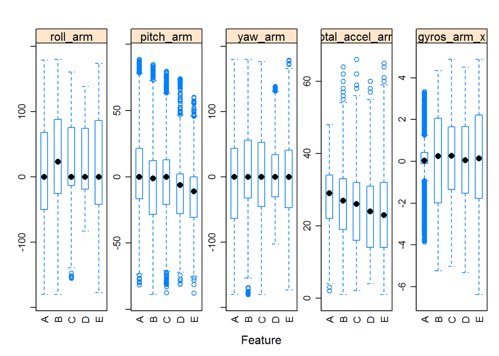

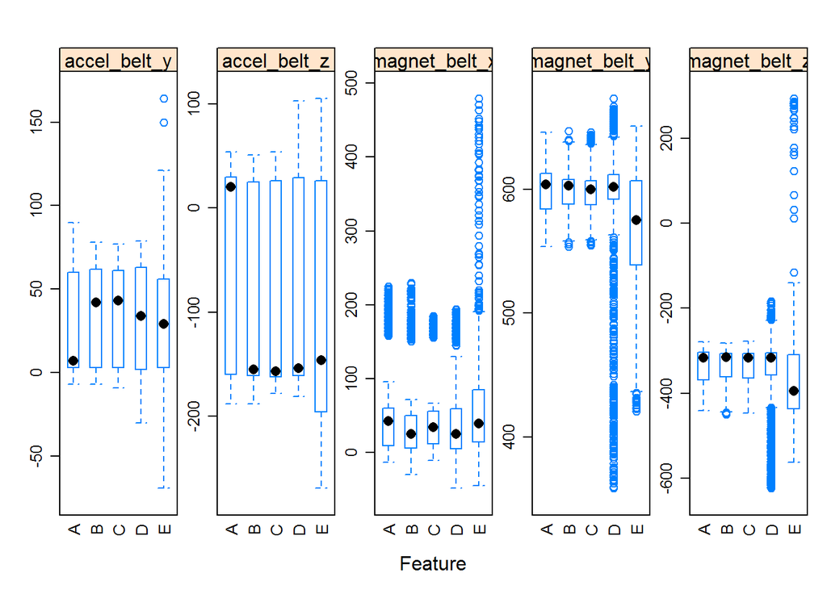

## Model Selection

FOr the classificaton exercise I’ve chosen to use a Random Forest Model. The initial intention was use some sort of ensemble model as they have performed particularly well in competition however on inspection of the output of the Random Forest Output it was clear that the model was highly accurate and as such the need for an ensemble model was discounted. By segmenting the training data into a training and test set The estimate of the out of sample error for the model was 0.35%

```r
tr.obj<- preProcess(training, method="knnImpute")
upd.train <- predict(tr.obj, newdata=training)
upd.test <- predict(tr.obj, newdata=testing)
upd.val <- predict(tr.obj, newdata=validation)
```

```r
caret::confusionMatrix(test.outcome, testing$classe)
```

```
## Confusion Matrix and Statistics
##
##           Reference
## Prediction    A    B    C    D    E
##          A 1674    5    0    0    0
##          B    0 1133    3    0    0
##          C    0    1 1023    8    0
##          D    0    0    0  956    3
##          E    0    0    0    0 1079
##
## Overall Statistics
##
##                Accuracy : 0.9966
##                  95% CI : (0.9948, 0.9979)
##     No Information Rate : 0.2845
##     P-Value [Acc > NIR] : < 2.2e-16
##
##                   Kappa : 0.9957
##  Mcnemar's Test P-Value : NA
##
## Statistics by Class:
##
##                      Class: A Class: B Class: C Class: D Class: E
## Sensitivity            1.0000   0.9947   0.9971   0.9917   0.9972
## Specificity            0.9988   0.9994   0.9981   0.9994   1.0000
## Pos Pred Value         0.9970   0.9974   0.9913   0.9969   1.0000
## Neg Pred Value         1.0000   0.9987   0.9994   0.9984   0.9994
## Prevalence             0.2845   0.1935   0.1743   0.1638   0.1839
## Detection Rate         0.2845   0.1925   0.1738   0.1624   0.1833
## Detection Prevalence   0.2853   0.1930   0.1754   0.1630   0.1833
## Balanced Accuracy      0.9994   0.9971   0.9976   0.9955   0.9986
```

## Model detail

The Random Forest Model was trained using 10 fold cross validation to improve accuracy during the selection of predictors

```r
fit
```

```
## Random Forest
##
## 13737 samples
##    54 predictor
##     5 classes: 'A', 'B', 'C', 'D', 'E'
##
## No pre-processing
## Resampling: Cross-Validated (10 fold)
## Summary of sample sizes: 12362, 12364, 12363, 12364, 12365, 12363, ...
## Resampling results across tuning parameters:
##
##   mtry  Accuracy   Kappa
##    2    0.9950494  0.9937377
##   28    0.9974526  0.9967777
##   54    0.9958511  0.9947517
##
## Accuracy was used to select the optimal model using  the largest value.
## The final value used for the model was mtry = 28.
```

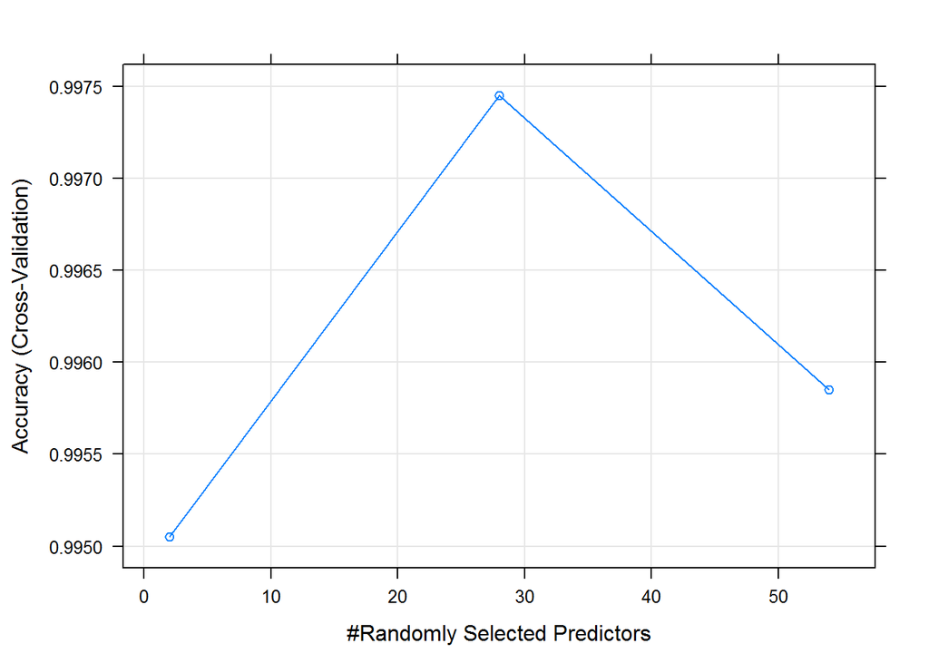

```r
plot(fit)
```

## Appendix

### GBM Model Performance

```
## Confusion Matrix and Statistics
##
##           Reference
## Prediction    A    B    C    D    E
##          A 1670   11    0    2    0
##          B    4 1116   14    2    3
##          C    0   12 1009   22    0
##          D    0    0    3  938   11
##          E    0    0    0    0 1068
##
## Overall Statistics
##
##                Accuracy : 0.9857
##                  95% CI : (0.9824, 0.9886)
##     No Information Rate : 0.2845
##     P-Value [Acc > NIR] : < 2.2e-16
##
##                   Kappa : 0.9819
##  Mcnemar's Test P-Value : NA
##
## Statistics by Class:
##
##                      Class: A Class: B Class: C Class: D Class: E
## Sensitivity            0.9976   0.9798   0.9834   0.9730   0.9871
## Specificity            0.9969   0.9952   0.9930   0.9972   1.0000
## Pos Pred Value         0.9923   0.9798   0.9674   0.9853   1.0000
## Neg Pred Value         0.9990   0.9952   0.9965   0.9947   0.9971
## Prevalence             0.2845   0.1935   0.1743   0.1638   0.1839
## Detection Rate         0.2838   0.1896   0.1715   0.1594   0.1815
## Detection Prevalence   0.2860   0.1935   0.1772   0.1618   0.1815
## Balanced Accuracy      0.9973   0.9875   0.9882   0.9851   0.9935
```